# TU256 Probability and Statistical Inference

PSI CA Part II

Panagiotis Pnevmatikatos

# 1. Introduction

This statistical analysis was designed to investigate whether a range of film’s attributes like votes crowd sourced from the imdb website, reviews written from authorized film critics, the release decade of the film, the genre etc, impact on a imdb rating. The dataset used in this analysis contains data collected from 2000 records listed on imdb. The dataset was download from kaggle in the form of csv file from https://www.kaggle.com/datasets/prishasawhney/imdb-dataset-top-2000-movies/data. (It is also contained in the zip file, next to the present report).

### 1.1 The Research Question

The research question investigated in this research is: How do film’s attributes like votes crowd sourced from the imdb website, reviews written from authorized film critics, the release decade of the film, the genre etc, impact on a imdb rating? The dataset contain a variety of attributes and it was well formatted. However, some minor data cleansing had to happen and sanitize the release year, convert the abbreviated value gross value to integer (eg $5.54M to 5,540,000), sanitize the column name, and create derived columns (see table 3)

### 1.2 The Variables

**Table 1: measurements included in the dataset**

| Concept | Measurement Instrument Used | Variable Type |
| --- | --- | --- |
| imdb rating | Aggregated user ratings for the film in the imdb site | Continuous |
| votes | Number of votes received by the movie | Discrete |
| metascore | Metascore of the movie; a weighted average of the reviews from a large group of respected critics | Continuous |
| release year | The Year of Release | Discrete |
| gross | Gross value of the movie | Discrete |
| duration | The running time of the movie (in minutes) | Discrete |

The dataset also contains categorical film attributes. Details of the variables and potential values are included in Table 2 below.

**Table 2: measurements included in the dataset**

| Concept | Description/Possible Values | Variable Type |
| --- | --- | --- |
| genre | the genre of the film, variety of values | Nominal |
| director | the director of the film, variety of values | Nominal |
| cast | the leading actor of the film, variety of values | Nominal |

On top of the dataset’s existing columns, we have created dynamically derived columns like a set of boolean columns expressing whether a film belongs to a genre category or not and a release_decade column

**Table 3: derived columns and variables**

| Concept | Description/Possible Values | Variable Type |
| --- | --- | --- |
| genre_comedy | whether the film is a comedy or not/TRUE, FALSE | Binary Nominal |
| release_decade | 1920, 1930, …, 2010 | Nominal with multiple categories |

### 1.3 Hypotheses

This research question was investigated through a series of hypotheses tests. The following hypotheses were investigated:

**Table 4: Hypotheses investigated**

[output not shown]

The data for each of the variables of interest was inspected to establish whether the level of missing data represented a source of bias. Using the guidance of Tabachnick and Fidell (2016 neither the proportion nor pattern of missing data represent a source of concern see Figure 1.

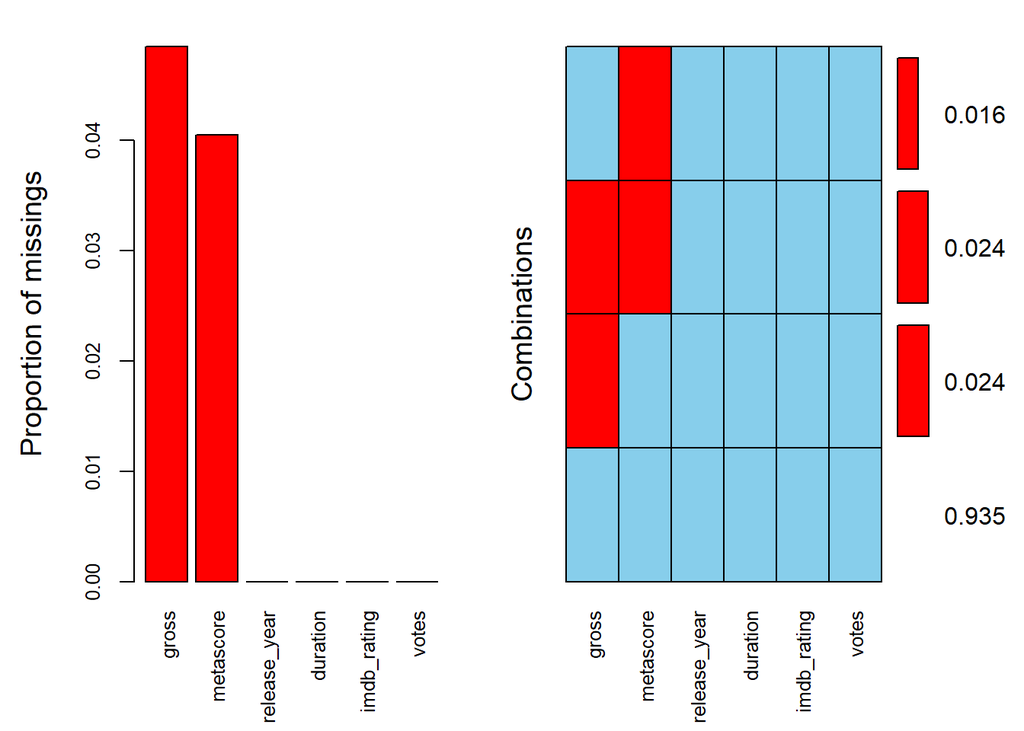

**Figure 1: Inspection of Missing Data**

```
##
##  Variables sorted by number of missings:
##      Variable  Count
##         gross 0.0485
##     metascore 0.0405
##  release_year 0.0000
##      duration 0.0000
##   imdb_rating 0.0000
##         votes 0.0000
```

```
##
##  Missings per variable:
##      Variable Count
##     metascore    81
##         gross    97
##  release_year     0
##      duration     0
##   imdb_rating     0
##         votes     0
##
##  Missings in combinations of variables:
##  Combinations Count Percent
##   0:0:0:0:0:0  1870   93.50
##   0:1:0:0:0:0    49    2.45
##   1:0:0:0:0:0    33    1.65
##   1:1:0:0:0:0    48    2.40
```

# 2. Hypotheses

## 2.1 Relationship between metascore and imdb rating

H0: There is no relationship between a film’s metascore and their imdb rating.  
Ha: There is a relationship between a film’s metascore and their imdb rating.

### 2.1.2 Inspection of metascore

Metascore scores were assessed for normality. Visual inspection of the histogram and QQ-Plot (see Figure 2 and Figure 3) identified some issues with skewness and kurtosis. Neither the standardized score for kurtosis (-4.73) nor the standardized score for skewness (-1.44) can be considered acceptable using the criteria proposed by Curran, West and Finch (1996). However as 100% (> 99%) of standardized scores fall within the bounds of +/- 3.29, using the guidance of Field, Miles and Field (2013), the data can be considered to approximate a normal distribution (m=61.04, sd=17.94, n=1919).

**Descriptive statistics of metascore**

```
##       median         mean      SE.mean CI.mean.0.95          var      std.dev
##   61.0000000   61.0442939    0.4094773    0.8030675  321.7618535   17.9377215
##     coef.var
##    0.2938476
```

**Visualizations of metascore**

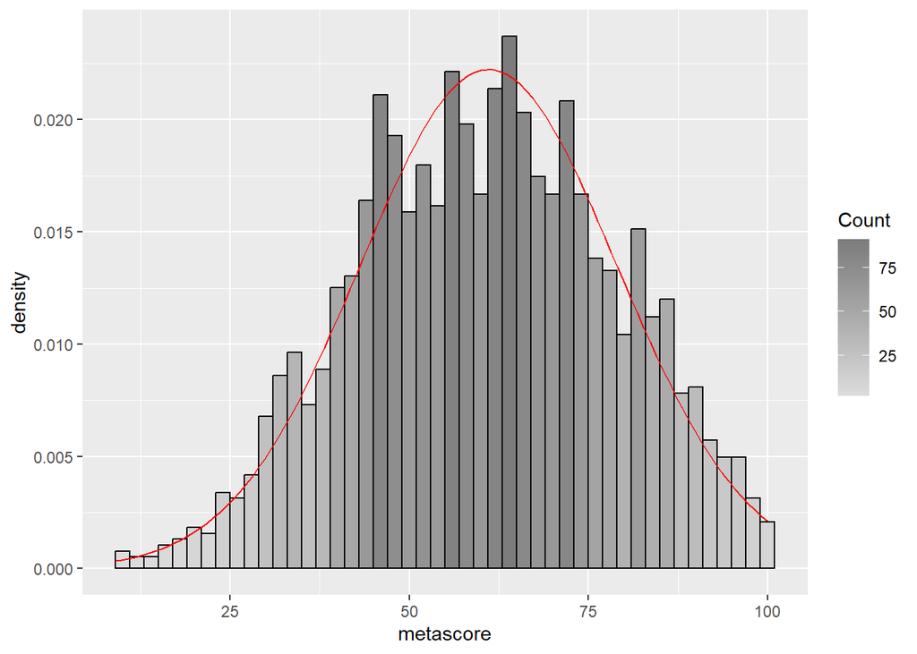

**Figure 2: Histogram for metascore**

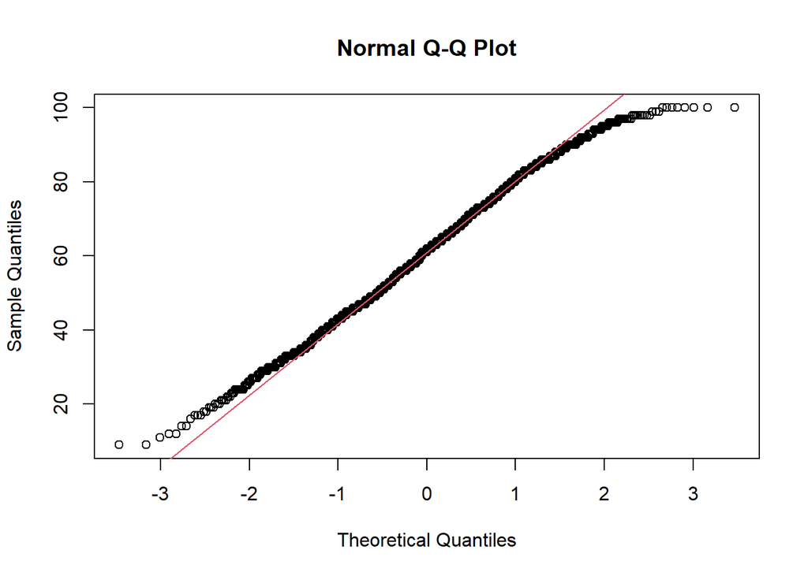

**Figure 3: QQPlot for metascore**

### 2.1.2 Inspection of imdb rating

Imdb rating scores were assessed for normality. Visual inspection of the histogram and QQ-Plot (see Figure 4 and Figure 5) identified some issues with skewness and kurtosis. While the standardized score for kurtosis (30) could be considered acceptable using the criteria proposed by Curran, West and Finch (1996), but the standardized score for skewness (-19.74) was outside the acceptable range. However as 99.25% (> 99%)of standardized scores fall within the bounds of +/- 3.29, using the guidance of Field, Miles and Field (2012), the data can be considered to approximate a normal distribution (m=6.92, sd=0.96, n=2000).

**Descriptive statistics of imdb rating**

```
##       median         mean      SE.mean CI.mean.0.95          var      std.dev
##   7.00000000   6.92260000   0.02136827   0.04190641   0.91320584   0.95561804
##     coef.var
##   0.13804323
```

**Visualizations of imdb rating**

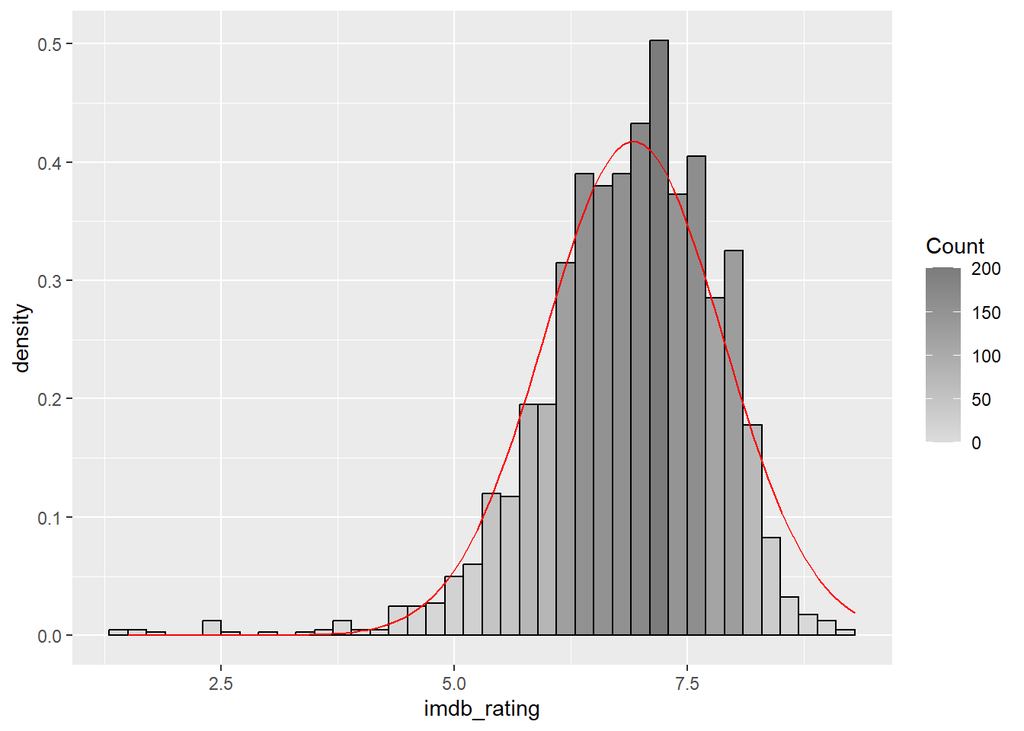

**Figure 4: Histogram for imdb rating**

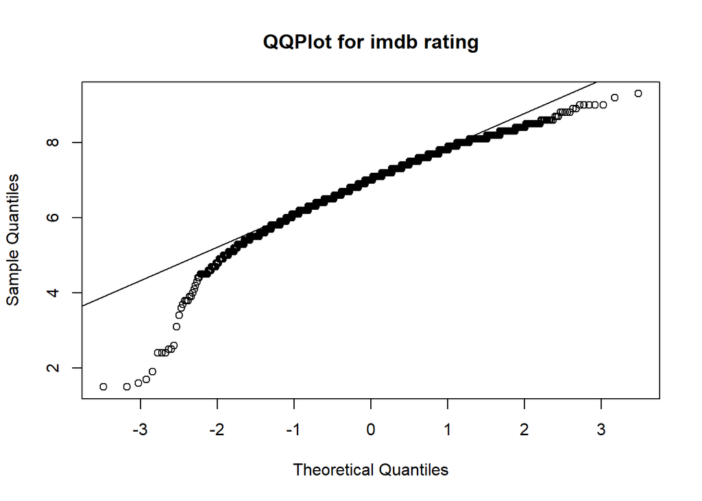

**Figure 5: QQPlot for imdb rating**

### 2.1.3 Inspection film’s metascore and rating covariance

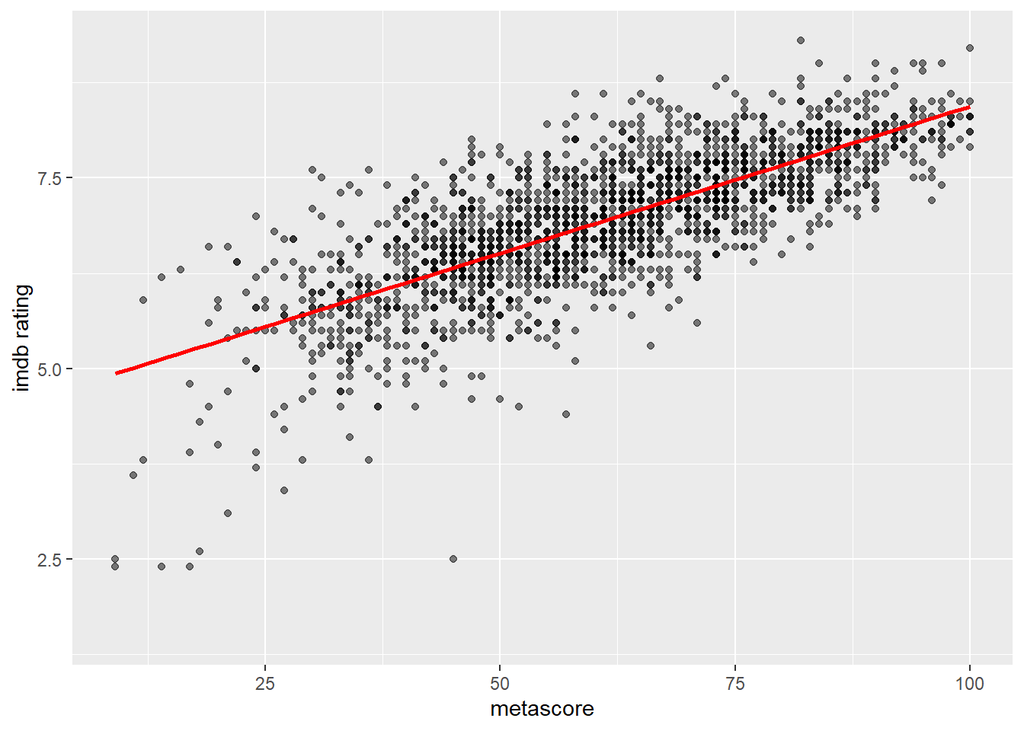

**Figure 6: Scatterplot for metascore and imdb rating**

### 2.1.4 Pearson’s correlation test on metascore and rating

As both metascore and imdb rating data can be considered approximately normal a Pearson’s correlation test can be used to test this hypothesis

```r
#Pearson Correlation - this is the correct test for this data
corstat_metascore_rating<-stats::cor.test(imdb$metascore, imdb$imdb_rating, method='pearson')
corstat_metascore_rating
```

```
##
##  Pearson's product-moment correlation
##
## data:  imdb$metascore and imdb$imdb_rating
## t = 50.645, df = 1917, p-value < 2.2e-16
## alternative hypothesis: true correlation is not equal to 0
## 95 percent confidence interval:
##  0.7366863 0.7750078
## sample estimates:
##       cor
## 0.7564956
```

## 2.2 Relationship between film’s votes and imdb rating

H0: There is no relationship between a film’s votes and their imdb rating.  
Ha: There is a relationship between a film’s votes and their imdb rating.

### 2.2.1 Inspection of film’s votes

**Descriptive statistics of imdb rating**

[output not shown]

**Visualizations of votes**

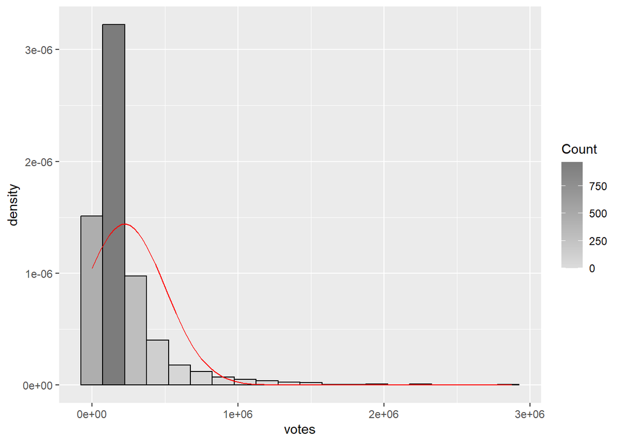

**Figure 7: Histogram for votes**

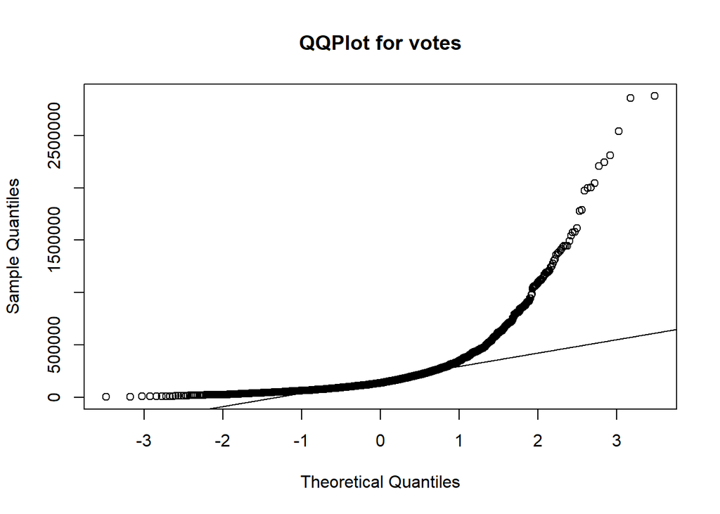

**Figure 8: QQPlot for votes**

### 2.2.2 Inspection film’s imdb rating

The variable imdb rating has been assessed in 2.1.2

### 2.2.3 Inspection film’s votes and imdb rating covariance

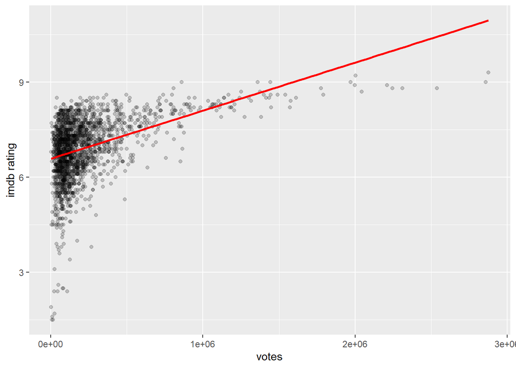

**Figure 9: Scatterplot for votes and imdb rating**

### 2.2.5 Conclusion on Pearson’s correlation test on votes and rating

```
##
##  Pearson's product-moment correlation
##
## data:  imdb$votes and imdb$imdb_rating
## t = 21.835, df = 1998, p-value < 2.2e-16
## alternative hypothesis: true correlation is not equal to 0
## 95 percent confidence interval:
##  0.4028463 0.4736457
## sample estimates:
##       cor
## 0.4389271
```

## 2.3 Difference in imdb ratings for films which are comedies and films which are not

H0: There is no difference between the imdb rating for films which are comedies and films which are not.  
Ha: There is a difference between the imdb rating for films which are comedies and films which are not.

### 2.3.1 Inspection of film’s comedy status

No missing data were found in film genre and as result in genre_comedy (which derives from the column genre).  
From our film data set, 709 films are comedies while 1291 are not comedies (see Figure 10).

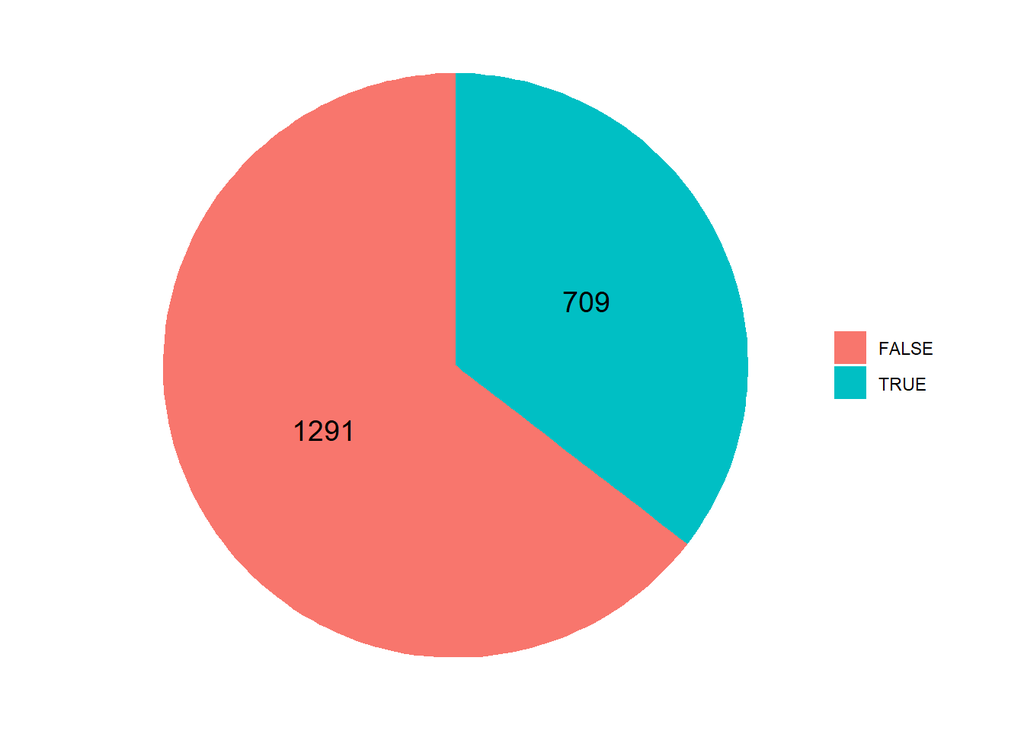

**Figure 10: Proportions of Comedy films**

### 2.3.2 Inspection of film’s imdb ratings by genre group

#### 2.3.2.1 Inspection of film’s imdb ratings variable as a whole

The variable imdb rating has been assessed in 2.1.2 and has been found to approximate normal distribution

#### 2.3.2.2 Inspection of film’s imdb ratings by genre group

The two groups (comedy/non comedy) of imdb ratings were assessed for normality. Visual inspection of the histogram identified some issues with skewness and kurtosis. However, as over 95% of standardized scores fall within the bounds of +/- 1.96 (as percentages were calculated to 96.4739069% and 95.9721146%). Therefore, using the guidance of Field, Miles and Field (2012), both groups can be considered to approximate the normal distribution with the comedy group distribution attributes as (m=6.68, sd=0.95, n=709) and the non comedy group ones as (m=7.06, sd=0.93, n=1291).

**Descriptive statistics of the imdb ratings by group**

```
##     item group1 vars    n     mean        sd median  trimmed     mad min max
## X11    1  FALSE    1 1291 7.057940 0.9318923    7.2 7.123233 0.88956 1.7 9.3
## X12    2   TRUE    1  709 6.676164 0.9496707    6.8 6.738313 0.74130 1.5 8.6
##     range      skew kurtosis         se
## X11   7.6 -1.017892 2.648106 0.02593598
## X12   7.1 -1.310348 4.611690 0.03566563
```

**Visualisations of imdb rating by group**  
Both film groups plotted along with their density function in the same Histogram. Also Box plot of both groups (see Figure 11, 12)

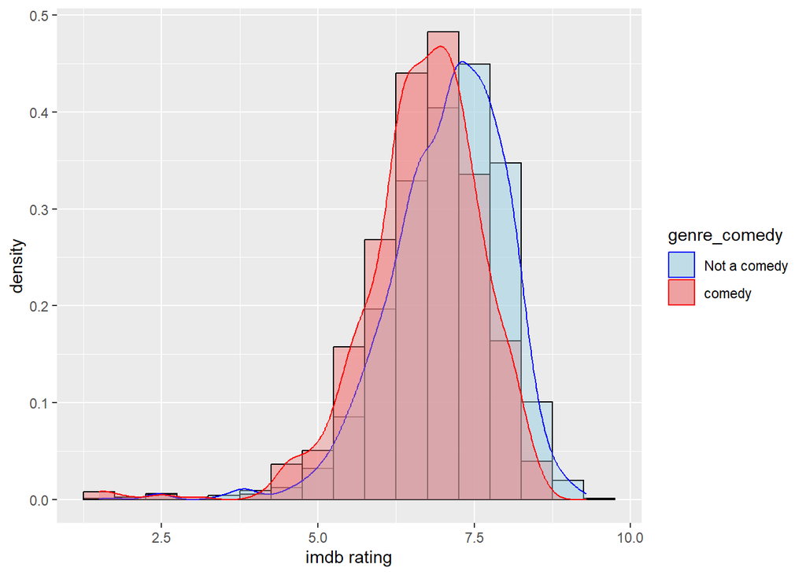

**Figure 11: Histogram and Density Plot of imdb rating by comedy Status**

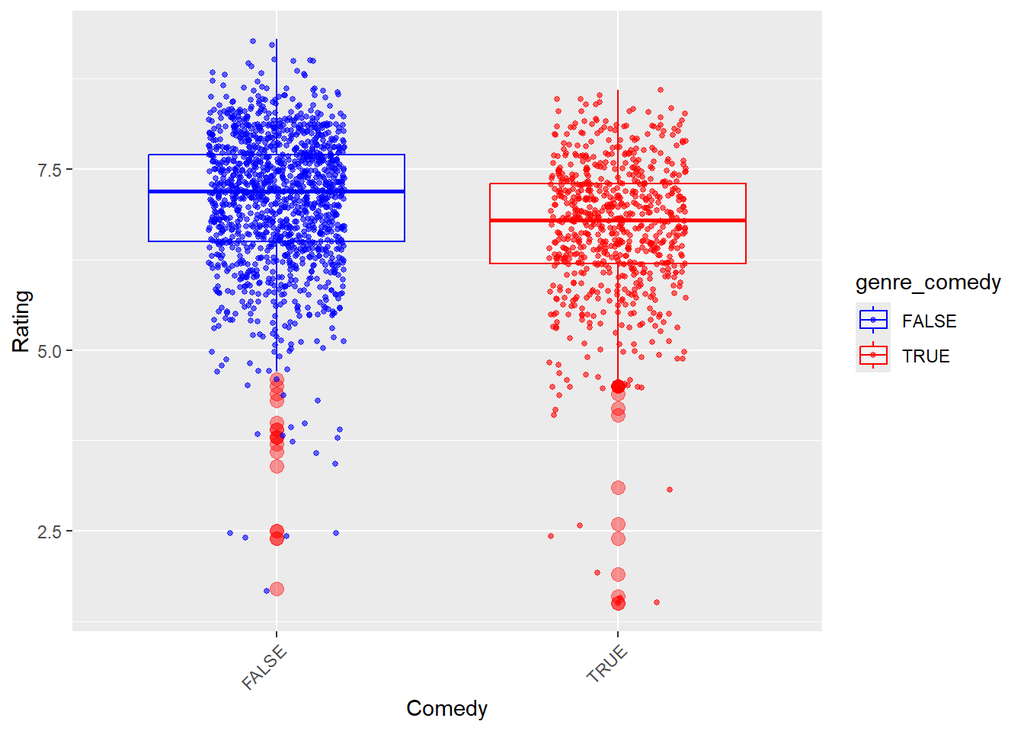

**Figure 12: Box Plots of imdb rating by comedy Status**

### 2.3.3 Test for homogeneity of variance of film’s imdb ratings by genre group

Furthermore, the Levene test for homogeneity of variance resulted a p-value=0.6629367 therefore the variances can be considered equal.

**Levene test**

```
## Levene's Test for Homogeneity of Variance (center = median)
##         Df F value Pr(>F)
## group    1    0.19 0.6629
##       1998
```

### 2.3.4 Two Sample t-test to compare ratings for films which are comedies and films which are not

The Levene test for homogeneity of variance with a p-value=0.6629367 indicates the variances can be considered equal. Therefore we procced with a two sample t-test

**TWO Sample t-test**

```
##
##  Two Sample t-test
##
## data:  imdb_rating by genre_comedy
## t = 8.705, df = 1998, p-value < 2.2e-16
## alternative hypothesis: true difference in means between group FALSE and group TRUE is not equal to 0
## 95 percent confidence interval:
##  0.2957658 0.4677861
## sample estimates:
## mean in group FALSE  mean in group TRUE
##            7.057940            6.676164
```

### 2.3.5 Conclusion on comparison of ratings for films which are comedies and films which are not

**Cohen’s d effect size**

```
## d    |       95% CI
## -------------------
## 0.39 | [0.30, 0.48]
```

## 2.4 Difference in imdb rating for films released in different decades

H0: There are no differences between the imdb rating for films with different release decades.  
Ha: There are differences between the imdb rating for films with different release decades.

### 2.4.1 Inspection of film’s release decade

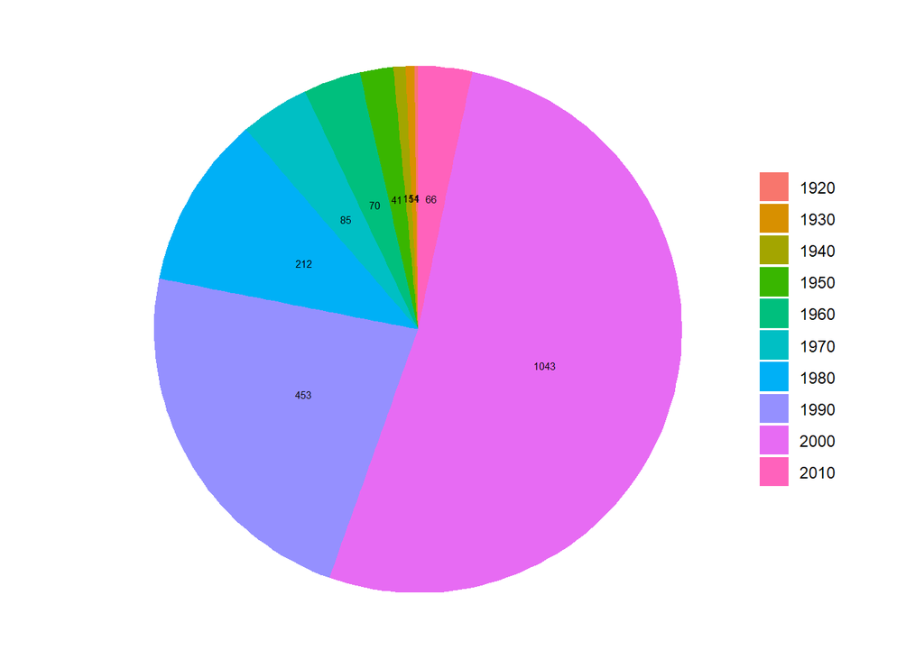

**Figure 13: Proportions of film ratings for each decade**

### 2.4.2 Inspection of film’s imdb rating by decade

#### 2.4.2.1 Inspection of film’s imdb ratings variable as a whole

The variable imdb rating has been assessed in 2.1.2

#### 2.4.2.2 Inspection of film’s imdb ratings variable by decade

**Descriptive statistics of the imdb ratings by decade**

```
##      group1    n     mean         sd median     mad min max range        skew   kurtosis         se
## X11    1920    4 8.175000 0.09574271   8.15 0.07413 8.1 8.3   0.2  0.32046114 -2.0841942 0.04787136
## X12    1930   11 8.081818 0.28919952   8.10 0.29652 7.6 8.5   0.9 -0.01621436 -1.2945562 0.08719694
## X13    1940   15 8.140000 0.20976177   8.10 0.29652 7.9 8.6   0.7  0.49926768 -0.7620937 0.05416026
## X14    1950   41 8.051220 0.32948593   8.10 0.29652 7.3 9.0   1.7  0.08335115  0.5513324 0.05145706
## X15    1960   70 7.678571 0.50787790   7.70 0.44478 6.5 8.8   2.3 -0.34330590 -0.4718875 0.06070302
## X16    1970   85 7.568235 0.60831770   7.60 0.59304 5.8 9.2   3.4 -0.41277563  0.8583136 0.06598132
## X17    1980  212 7.223113 0.75135500   7.30 0.74130 3.7 8.7   5.0 -1.05449099  2.5773789 0.05160327
## X18    1990  453 6.981015 0.85852922   7.10 0.74130 3.6 9.3   5.7 -0.68903256  1.4388569 0.04033722
## X19    2000 1043 6.691371 0.96373909   6.70 0.88956 1.5 9.0   7.5 -1.19569742  4.0616849 0.02984127
## X110   2010   66 6.330303 1.11050504   6.35 0.88956 1.7 8.8   7.1 -0.88702064  3.2427411 0.13669372
```

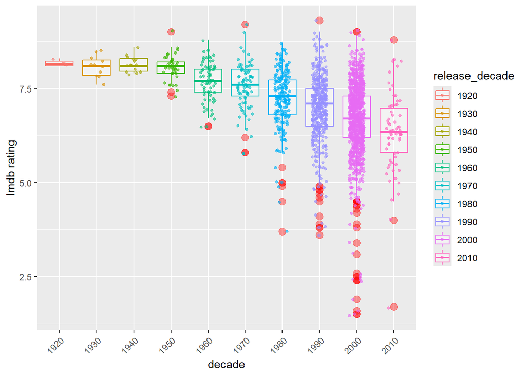

### 2.4.3 Bartlett test for homogeneity of variance

```
##
##  Bartlett test of homogeneity of variances
##
## data:  imdb_rating by release_decade
## Bartlett's K-squared = 175.62, df = 9, p-value < 2.2e-16
```

### 2.4.4 Anova omnibus test

```
##
##  One-way analysis of means
##
## data:  imdb_rating and as.factor(release_decade)
## F = 38.473, num df = 9, denom df = 1990, p-value < 2.2e-16
```

```
##              term group1 group2 null.value    estimate   conf.low    conf.high    p.adj p.adj.signif
## 1  release_decade   1920   1930          0 -0.09318182 -1.7278835  1.541519908 1.00e+00           ns
## 2  release_decade   1920   1940          0 -0.03500000 -1.6105072  1.540507247 1.00e+00           ns
## 3  release_decade   1920   1950          0 -0.12378049 -1.5903531  1.342792099 1.00e+00           ns
## 4  release_decade   1920   1960          0 -0.49642857 -1.9357443  0.942887167 9.86e-01           ns
## 5  release_decade   1920   1970          0 -0.60676471 -2.0391992  0.825669802 9.44e-01           ns
## 6  release_decade   1920   1980          0 -0.95188679 -2.3649064  0.461132786 5.04e-01           ns
## 7  release_decade   1920   1990          0 -1.19398455 -2.6000264  0.212057257 1.78e-01           ns
## 8  release_decade   1920   2000          0 -1.48362895 -2.8861856 -0.081072275 2.82e-02            *
## 9  release_decade   1920   2010          0 -1.84469697 -3.2863684 -0.403025558 2.13e-03           **
## 10 release_decade   1930   1940          0  0.05818182 -1.0532016  1.169565285 1.00e+00           ns
## 11 release_decade   1930   1950          0 -0.03059867 -0.9812749  0.920077551 1.00e+00           ns
## 12 release_decade   1930   1960          0 -0.40324675 -1.3113106  0.504817076 9.25e-01           ns
## 13 release_decade   1930   1970          0 -0.51358289 -1.4106998  0.383534019 7.27e-01           ns
## 14 release_decade   1930   1980          0 -0.85870497 -1.7244847  0.007074705 5.40e-02           ns
```

[output cut: 31 more lines]

```
## Eta2 |       95% CI
## -------------------
## 0.15 | [0.12, 1.00]
##
## - One-sided CIs: upper bound fixed at [1.00].
```

### 2.4.5 Conclusion on comparison of film ratings for films released in different decades

A one-way between-groups analysis of variance (ANOVA) was conducted to explore the impact of film’s release decade on film rating. The films are divided into ten groups according to the decade they were released (from 1920s to 2010s). There was a statistically significant difference in imdb ratings for the ten decage groups: (F(9, 1990)= 38.473, p<0.05. The effect size, calculated using eta squared was (0.15). Post-hoc comparisons using the Tukey HSD test indicated statistically significant differences between several groups that can be observed in the table bellow

```
##    group1 group2
## 8    1920   2000
## 9    1920   2010
## 15   1930   1990
## 16   1930   2000
## 17   1930   2010
## 21   1940   1980
## 22   1940   1990
## 23   1940   2000
## 24   1940   2010
## 27   1950   1980
## 28   1950   1990
## 29   1950   2000
## 30   1950   2010
## 32   1960   1980
## 33   1960   1990
## 34   1960   2000
## 35   1960   2010
## 37   1970   1990
## 38   1970   2000
## 39   1970   2010
## 40   1980   1990
## 41   1980   2000
## 42   1980   2010
## 43   1990   2000
## 44   1990   2010
## 45   2000   2010
```

## 2.5 Relationship between a film’s genre (comendy/non comedy) and decade it was released

H0: There is no relationship between a film’s genre (comedy/non comedy) and the decade it was released.  
Ha: There is a relationship between a film’s genre (comedy/non comedy) and the decade it was released.

### 2.5.2 Inspection of genre (comedy/non comedy)

The variable genre_comedy has been assessed in 2.3.1. The proportion of films in each genre group (comedy/non-comedy) is shown in Figure 10.

### 2.5.3 Inspection of films genre (comedy/non comedy) by release decade

Table 5 shows the numbers of films in each decade in each genre group (comedy/non-comedy).

Release Decade and Genre (Comedy/Non Comedy) Counts

| Release decade | Non-Comedy | Comedy |
| --- | --- | --- |
| 1920 | 1 | 3 |
| 1930 | 7 | 4 |
| 1940 | 14 | 1 |
| 1950 | 33 | 8 |
| 1960 | 52 | 18 |
| 1970 | 66 | 19 |
| 1980 | 131 | 81 |
| 1990 | 282 | 171 |
| 2000 | 664 | 379 |
| 2010 | 41 | 25 |

### 2.5.4 Test the independance and measure the association of film’s genre (comedy/non comedy) and the film’s release decade

As both release decade and genre comedy are represented by nominal variables, a Chi-squared test of independence can be used to test the hypothesis.

Pearson’s chi-square test

```
##
##  Pearson's Chi-squared test
##
## data:  contigency_decade_comedy
## X-squared = 24.271, df = 9, p-value = 0.003893
```

Expected Frequencies

```
##               genre_comedy
## release_decade    FALSE     TRUE
##           1920   2.5820   1.4180
##           1930   7.1005   3.8995
##           1940   9.6825   5.3175
##           1950  26.4655  14.5345
##           1960  45.1850  24.8150
##           1970  54.8675  30.1325
##           1980 136.8460  75.1540
##           1990 292.4115 160.5885
##           2000 673.2565 369.7435
##           2010  42.6030  23.3970
```

Pearson chi-square test’s p-value suggests an association between genre and release decade and by observing the adjusted residuals table and our contigency table we can identify the decades 1940, 1950 and 1970 as less likely to releasing comedies

Adjusted residuals

```
##               genre_comedy
## release_decade       FALSE        TRUE
##           1920 -1.65521712  1.65521712
##           1930 -0.06352009  0.06352009
##           1940  2.33918848 -2.33918848
##           1950  2.15556921 -2.15556921
##           1960  1.73339261 -1.73339261
##           1970  2.57963111 -2.57963111
##           1980 -0.88769930  0.88769930
##           1990 -1.16272711  1.16272711
##           2000 -0.86617857  0.86617857
##           2010 -0.41946147  0.41946147
```

However, to measure the association between film’s comedy status and film’s release decade we can Calculate cramer’s V

```
## [1] 0.1101607
```

### 2.5.5 Conclusion on examining the relation between film’s genre (comedy/non comedy) and release decade

A Chi-Square test for independence indicated a statistically significant association between film’s comedy genre and the film’s release decade: χ²(9, n=2000)=24.271, p=0.0039<0.05.

While the association is statistically significant the small effect size that is resulted by the calculation of Cramer’s V= 0.11 suggests the association is relatively weak.

# 3. Conclusions

As a result of the investigations and the tests conducted in section 2, the following the following conclusions have been drawn:

1. **Pair 1**
   - H0: There is no relationship between a film’s metascore and their imdb rating.
   - Ha: There is a relationship between a film’s metascore and their imdb rating.
   - **Conclusion**: A strong, positive, statistically significant correlation was found between a film’s metascore and their imdb rating. There is therefore evidence to reject the null hypothesis in favour of the alternate hypothesis and the result suggests that higher film metascores are associated with higher ratings.
2. **Pair 2**
   - H0: There is no relationship between a film’s votes and their imdb rating.
   - Ha: There is a relationship between a film’s votes and their imdb rating.
   - **Conclusion**: A moderate, positive, statistically significant correlation was found between a film’s votes and their imdb rating. There is therefore evidence to reject the null hypothesis in favour of the alternate hypothesis and the result suggests that higher film votes are associated with higher ratings.
3. **Pair 3**
   - H0: There is no difference between the imdb rating for films which are comedies and films which are not.
   - Ha: There is a difference between the imdb rating for films which are comedies and films which are not.
   - **Conclusion**: A statistically extremely significant difference in the film rating was found between comedy films and non-comedy films. There is therefore evidence to support rejecting the null hypothesis in favour of the alternate hypothesis.
4. **Pair 4**
   - H0: There are no differences between the imdb rating for films with different release decades.
   - Ha: There are differences between the imdb rating for films with different release decades.
   - **Conclusion**: A statistically significant difference in film ratings was found for films released in different decades. Therefore there is evidence to support rejecting the null hypothesis in favour of the alternate hypothesis.
5. **Pair 5**
   - H0: There is no relationship between a film’s genre (comedy/non comedy) and the decade it was released.
   - Ha: There is a relationship between a film’s genre (comedy/non comedy) and the decade it was released.
   - **Conclusion**: A statistically significant association was found between a film’s genre and its release decade. However, the association between film’s genre and film’s release decade was found to be relatively weak. Therefore while there is evidence to reject the null hypothesis in favour of the alternate hypothesis and the result suggests that comedies tend to be released durring certain decades more often than other genre films.

# References

Cohen, S., Kamarck, T. & Mermelstein, R. (1983). A global measure of perceived stress. Journal of Health and Social Behavior, 24, 385–96.  
Cohen, J. (1988). Statistical power analysis for the behavioral sciences (2nd ed.). Hillside, NJ: Lawrence Erlbaum Associates.  
Crowne, D.P. & Marlowe, D. (1960). A new scale of social desirability independent of psychopathology. Journal of Consulting Psychology, 24, 349–54.  
Curran, Patrick J., Stephen G. West, and John F. Finch. (1996). “The robustness of test statistics to nonnormality and specification error in confirmatory factor analysis.” Psychological methods 1.1 (1996): 16., E., Emmons, R.A., Larson, R.J. & Griffin, S. (1985). The Satisfaction with Life scale. Journal of Personality Assessment, 49, 71–6.  
Field, A., Field Z. & Miles J.(2012). Discovering statistics using IBM SPSS statistics. Sage publications limited,  
Pallant, J. (2000). Development and validation of a scale to measure perceived control of internal states. Journal of Personality Assessment, 75, 2, 308–37. Pearlin, L. & Schooler, C. (1978). The structure of coping. Journal of Health and Social Behavior, 19, 2–21.  
Rosenberg, M. (1965). Society and the adolescent self-image. Princeton, NJ: Princeton University Press.  
Scheier, M.F. & Carver, C.S. (1985). Optimism, coping and health: An assessment and implications of generalized outcome expectancies. Health Psychology, 4, 219–47.  
Watson, D., Clark, L.A. & Tellegen, A. (1988). Development and validation of brief measures of positive and negative affect: The PANAS scales. Journal of Personality and Social Psychology, 54, 1063–70.  
Tabachnik and Fidell, Using Multivariate Statistics, 6th Edition, Pearson.